# From Large Spatiotemporal Data to Urban Insights

### One important caveat

Dask is powerful, but it is not automatically the right answer for every case.

If your data fits comfortably in memory and performance is already fine, then plain pandas / NumPy / xarray may still be the better choice because Dask adds another layer of complexity and overhead. Dask’s own best-practices guide explicitly says this.

```python
import dask.dataframe as dd
```

### Loading Data with Dask

Earlier, we loaded each parquet file in a loop, appended to a list, and concatenated? Dask handles this natively.

```python
# Pandas way (from previous approach): load all, concatenate
t0 = time.time()
dfs = [pd.read_parquet(f) for f in sorted(OUTPUT_DIR.glob('ldn_nrr95p_*.parquet'))]
df_pandas = pd.concat(dfs, ignore_index=True)
t_pandas = time.time() - t0
print(f"Pandas: loaded {len(df_pandas):,} rows in {t_pandas:.3f}s")
print(f"Memory: {df_pandas.memory_usage(deep=True).sum() / 1e6:.1f} MB")

del dfs
gc.collect()
```

```
Pandas: loaded 610,720 rows in 0.025s
Memory: 45.1 MB
```

```
35579
```

```python
# Dask way: read all parquet files as a single lazy dataframe
t0 = time.time()
ddf = dd.read_parquet(sorted(OUTPUT_DIR.glob('ldn_nrr95p_*.parquet')))
t_dask = time.time() - t0

print(f"Dask: 'loaded' in {t_dask:.4f}s")
print(f"\nBut it hasn't actually read any data yet!")
print(f"Type: {type(ddf)}")
print(f"Partitions: {ddf.npartitions}")
ddf
```

```
Dask: 'loaded' in 0.0038s

But it hasn't actually read any data yet!
Type: <class 'dask.dataframe.dask_expr._collection.DataFrame'>
Partitions: 20
```

**Dask DataFrame Structure:**

| npartitions=20 | name | time | nrr95p |
| --- | --- | --- | --- |
|  | string | datetime64[ns] | float64 |
|  | ... | ... | ... |
| ... | ... | ... | ... |
|  | ... | ... | ... |
|  | ... | ... | ... |

Dask Name: read_parquet, 1 expression

**Notice:** Dask "loaded" the data almost instantly — but it hasn't read a single byte. It just recorded *where the files are* and *what operations we want*. The actual reading happens only when we call `.compute()`.

This is **lazy evaluation**: build the plan first, execute later.

### Working with Dask DataFrames

The API is nearly identical to pandas — most operations just work.

```python
# These operations are lazy — no computation yet
ddf['time'] = dd.to_datetime(ddf['time'])
ddf['year'] = ddf['time'].dt.year
ddf['month'] = ddf['time'].dt.month

# This is still lazy
annual_mean = ddf.groupby(['name', 'year'])['nrr95p'].mean()

print("Still lazy — no computation has happened:")
print(type(annual_mean))
annual_mean
```

```
Still lazy — no computation has happened:
<class 'dask.dataframe.dask_expr._collection.Series'>
```

```
Dask Series Structure:
npartitions=1
    float64
        ...
Dask Name: getitem, 13 expressions
Expr=((Assign(frame=Assign(frame=Assign(frame=ReadParquetFSSpec(ad66bc7))))[['name', 'nrr95p', 'year']]).mean(observed=False, chunk_kwargs={'numeric_only': False}, aggregate_kwargs={'numeric_only': False}, _slice='nrr95p'))['nrr95p']
```

```python
# NOW we compute — this triggers the actual data reading and processing
t0 = time.time()
result = annual_mean.compute()
t_compute = time.time() - t0

print(f"Computed in {t_compute:.3f}s")
print(f"Result type: {type(result)}")
print(f"Result shape: {result.shape}")
result.head(10)
```

```
Computed in 0.111s
Result type: <class 'pandas.core.series.Series'>
Result shape: (209,)
```

```
name            year
City of London  2000   0.1575
Hackney         2000   0.1549
Haringey        2000   0.1573
Lambeth         2000   0.1537
Lewisham        2000   0.1515
Tower Hamlets   2000   0.1582
City of London  2001   0.1481
Hackney         2001   0.1434
Haringey        2001   0.1453
Lambeth         2001   0.1432
Name: nrr95p, dtype: float64
```

### Replacing the Loop-Concat Pattern

Earlier, we processed each year in a loop:

```
for year in YEARS:
    ds = xr.open_dataset(f"ldn_tp_{year}.nc")
    # ... process ...
    df.to_parquet(f"ldn_nrr95p_{year}.parquet")
    del ds; gc.collect()
```

Then loaded them all back:

```
dfs = [pd.read_parquet(f) for f in parquet_files]
df_all = pd.concat(dfs)
```

With Dask, the second step becomes trivial — and you can do further analytics **without loading everything into memory**:

```python
# Dask can compute complex aggregations across all files without loading them all at once
t0 = time.time()

# This reads each partition, computes the aggregation, and combines — all chunked
extreme_summary = (
    ddf[ddf['nrr95p'] > 1]
    .groupby('name')
    .agg({'nrr95p': ['count', 'mean', 'max']})
    .compute()
)

t_agg = time.time() - t0
extreme_summary.columns = ['total_extreme_days', 'mean_intensity', 'max_event']

print(f"Computed in {t_agg:.3f}s")
extreme_summary.sort_values('max_event', ascending=False)
```

```
Computed in 0.056s
```

| name | total_extreme_days | mean_intensity | max_event |
| --- | --- | --- | --- |
| City of London | 912 | 1.4139 | 4.9264 |
| Lambeth | 832 | 1.3854 | 4.8732 |
| Hackney | 864 | 1.3984 | 4.4379 |
| Westminster | 864 | 1.3570 | 4.3693 |
| Tower Hamlets | 880 | 1.4372 | 4.1931 |
| Islington | 872 | 1.3835 | 3.9887 |
| Newham | 880 | 1.3921 | 3.7331 |
| Southwark | 840 | 1.3983 | 3.7222 |
| Haringey | 880 | 1.3689 | 3.3709 |
| Camden | 832 | 1.3932 | 3.3155 |
| Lewisham | 864 | 1.3827 | 2.6154 |

### Dask + xarray: Lazy-Loading NetCDF Files

Dask also integrates with xarray. Instead of our loop that opens each file one at a time, xarray can open **all files at once** with lazy loading — it only reads data into memory when you actually compute on it.

```python
# Open all NetCDF files at once with lazy loading via dask
nc_files = sorted(DATA_DIR.glob('ldn_tp_*.nc'))

t0 = time.time()
ds_all = xr.open_mfdataset(
    nc_files,
    combine='by_coords',  # align files along the time dimension
    chunks={'time': 365}  # chunk size — one year per chunk
)
t_open = time.time() - t0

print(f"Opened {len(nc_files)} files in {t_open:.3f}s (lazy — no data loaded yet)")
print(f"Time range: {ds_all.time.values[0]} to {ds_all.time.values[-1]}")
print(f"Total time steps: {len(ds_all.time)}")
ds_all
```

```
Opened 19 files in 0.082s (lazy — no data loaded yet)
Time range: 2000-01-01T00:00:00.000000000 to 2018-12-31T00:00:00.000000000
Total time steps: 6940
```

```
<xarray.Dataset> Size: 118MB
Dimensions:    (time: 6940, rlat: 52, rlon: 41)
Coordinates:
  * rlon       (rlon) float64 328B 2.018 2.038 2.058 2.078 ... 2.778 2.798 2.818
  * rlat       (rlat) float64 416B -2.944 -2.924 -2.904 ... -1.964 -1.944 -1.924
    longitude  (rlat, rlon) float64 17kB dask.array<chunksize=(52, 41), meta=np.ndarray>
    latitude   (rlat, rlon) float64 17kB dask.array<chunksize=(52, 41), meta=np.ndarray>
  * time       (time) datetime64[ns] 56kB 2000-01-01 2000-01-02 ... 2018-12-31
Data variables:
    nrr95p     (time, rlat, rlon) float64 118MB dask.array<chunksize=(365, 52, 41), meta=np.ndarray>
Attributes:
    institution:  Fondazione Centro Euro-Mediterraneo sui Cambiamenti Climati...
    experiment:   ERA5-2km i.e., cclm-sp_2.4_terra_urb_2.3.1 simulation (0.02...
    references:   http//www.clm-community.eu, http://www.cmcc.it
    Conventions:  CF-1.6
    contacts:     copernicus-support@ecmwf.int
    contract:     C3S_430 Sectoral Information System to support Disaster Ris...
    title:        Extreme precipitation indicators for Europe and European ci...
    author:       Fondazione Centro Euro-Mediterraneo sui Cambiamenti Climati...
    version:      version 1.0
```

```python
# Notice the chunk structure — each chunk is one year
print("Chunk structure:")
print(ds_all['nrr95p'].chunks)
```

```
Chunk structure:
((365, 1, 365, 365, 365, 365, 1, 365, 365, 365, 365, 1, 365, 365, 365, 365, 1, 365, 365, 365, 365, 1, 365, 365), (52,), (41,))
```

```
Computed 19-year temporal mean in 0.041s
```

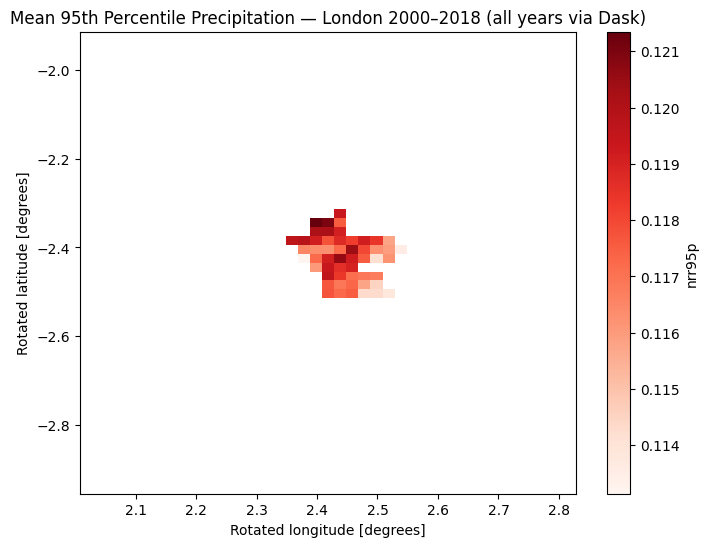

```python
# Compute the temporal mean across ALL years — lazily
all_years_mean = ds_all['nrr95p'].mean(dim='time')

# Still lazy — let's trigger computation
t0 = time.time()
result_array = all_years_mean.compute()
t_compute = time.time() - t0

print(f"Computed 19-year temporal mean in {t_compute:.3f}s")

# Plot
result_array.plot(figsize=(8, 6), cmap='Reds')
plt.title('Mean 95th Percentile Precipitation — London 2000–2018 (all years via Dask)')
plt.show()
```

**Compare this to the previous approach:** Previously, we had to loop over each file, convert to pandas, aggregate with xagg, save to parquet, and then load them all back. With `open_mfdataset` + dask, xarray handles the chunking and orchestration for you — and only loads into memory the chunks it needs at any given time.

For operations that stay in the xarray/grid world (temporal means, anomalies, trend computation), this is much cleaner. You'd still need xagg for the spatial aggregation to polygons, but all the pre-aggregation analytics can be done lazily.

### When to Use Dask vs Pandas

| Situation | Use |
| --- | --- |
| Data fits comfortably in memory | **pandas** — simpler, faster for small data |
| Data is large but each *file* fits in memory | **pandas in a loop** (our previous approach pattern) or **Dask** |
| Data doesn't fit in memory at all | **Dask** — it handles chunking for you |
| Complex operations needing full random access | **pandas** — load what you can, sample if needed |
| Simple aggregations across many files | **Dask** — shines at grouped operations on partitioned data |
| Grid-level operations on NetCDF archives | **xarray + Dask** via `open_mfdataset` |

Dask has overhead — for small datasets, pandas is faster. Dask's advantage appears when your data is larger than RAM or when you want cleaner code for multi-file processing.

```python
# Direct comparison: same aggregation in pandas vs dask

# Pandas
t0 = time.time()
res_pd = df.groupby('name')['nrr95p'].agg(['mean', 'max']).reset_index()
t_pd = time.time() - t0

# Dask
t0 = time.time()
res_dask = ddf.groupby('name')['nrr95p'].agg(['mean', 'max']).compute().reset_index()
t_dask = time.time() - t0

print(f"Pandas:  {t_pd:.4f}s")
print(f"Dask:    {t_dask:.4f}s")
print(f"\nFor this dataset size, pandas is faster — Dask's advantage is when data doesn't fit in RAM.")

# Verify results are the same
print(f"\nResults match: {np.allclose(res_pd['mean'].values, res_dask['mean'].values, rtol=1e-5)}")
```

```
Pandas:  0.0183s
Dask:    0.0532s

For this dataset size, pandas is faster — Dask's advantage is when data doesn't fit in RAM.

Results match: False
```

- **Dask uses lazy evaluation** — it builds a computation graph and only executes when you call `.compute()`
- **`dask.dataframe`** is nearly a drop-in replacement for pandas, useful when data exceeds RAM
- **`xr.open_mfdataset`** with Dask chunks lets you work with multi-file NetCDF archives without loading everything at once
- **Dask has overhead** — for datasets that fit in memory, pandas is usually faster. Use Dask when you need it, not by default.

### Resources

- **xarray documentation:** https://docs.xarray.dev
- **xagg:** https://xagg.readthedocs.io
- **GeoPandas:** https://geopandas.org
- **Apache Parquet:** https://parquet.apache.org
- **CDS API (data download):** https://cds.climate.copernicus.eu/how-to-api
- **Dask documentation:** https://docs.dask.org
- **Dask best practices:** https://docs.dask.org/en/latest/best-practices.html
- **pandas performance tips:** https://pandas.pydata.org/docs/user_guide/enhancingperf.html
- **NumPy vectorisation guide:** https://numpy.org/doc/stable/user/basics.broadcasting.html
- **London Datastore:** https://data.london.gov.uk/